# Risk Factor Analysis

## Outcome Variable

**Outcome Variable:** wast_rec90d

## Predictor Variables

**Intervention Variable:** meducyrs

**Adjustment Set:**

unadjusted

## Stratifying Variables

The analysis was stratified on these variable(s):

- agecat
- studyid
- country

## Data Summary

| agecat | studyid | country | meducyrs | wast_rec90d | n_cell | n | outcome_variable |
| --- | --- | --- | --- | --- | --- | --- | --- |
| 0-24 months | ki0047075b-MAL-ED | BANGLADESH | High | 0 | 7 | 87 | wast_rec90d |
| 0-24 months | ki0047075b-MAL-ED | BANGLADESH | High | 1 | 20 | 87 | wast_rec90d |
| 0-24 months | ki0047075b-MAL-ED | BANGLADESH | Low | 0 | 10 | 87 | wast_rec90d |
| 0-24 months | ki0047075b-MAL-ED | BANGLADESH | Low | 1 | 23 | 87 | wast_rec90d |
| 0-24 months | ki0047075b-MAL-ED | BANGLADESH | Medium | 0 | 6 | 87 | wast_rec90d |
| 0-24 months | ki0047075b-MAL-ED | BANGLADESH | Medium | 1 | 21 | 87 | wast_rec90d |
| 0-24 months | ki0047075b-MAL-ED | BRAZIL | High | 0 | 0 | 24 | wast_rec90d |
| 0-24 months | ki0047075b-MAL-ED | BRAZIL | High | 1 | 3 | 24 | wast_rec90d |
| 0-24 months | ki0047075b-MAL-ED | BRAZIL | Low | 0 | 4 | 24 | wast_rec90d |
| 0-24 months | ki0047075b-MAL-ED | BRAZIL | Low | 1 | 6 | 24 | wast_rec90d |
| 0-24 months | ki0047075b-MAL-ED | BRAZIL | Medium | 0 | 2 | 24 | wast_rec90d |
| 0-24 months | ki0047075b-MAL-ED | BRAZIL | Medium | 1 | 9 | 24 | wast_rec90d |
| 0-24 months | ki0047075b-MAL-ED | INDIA | High | 0 | 13 | 154 | wast_rec90d |
| 0-24 months | ki0047075b-MAL-ED | INDIA | High | 1 | 20 | 154 | wast_rec90d |
| 0-24 months | ki0047075b-MAL-ED | INDIA | Low | 0 | 20 | 154 | wast_rec90d |
| 0-24 months | ki0047075b-MAL-ED | INDIA | Low | 1 | 42 | 154 | wast_rec90d |
| 0-24 months | ki0047075b-MAL-ED | INDIA | Medium | 0 | 25 | 154 | wast_rec90d |
| 0-24 months | ki0047075b-MAL-ED | INDIA | Medium | 1 | 34 | 154 | wast_rec90d |
| 0-24 months | ki0047075b-MAL-ED | NEPAL | High | 0 | 2 | 93 | wast_rec90d |
| 0-24 months | ki0047075b-MAL-ED | NEPAL | High | 1 | 15 | 93 | wast_rec90d |
| 0-24 months | ki0047075b-MAL-ED | NEPAL | Low | 0 | 5 | 93 | wast_rec90d |
| 0-24 months | ki0047075b-MAL-ED | NEPAL | Low | 1 | 31 | 93 | wast_rec90d |
| 0-24 months | ki0047075b-MAL-ED | NEPAL | Medium | 0 | 10 | 93 | wast_rec90d |
| 0-24 months | ki0047075b-MAL-ED | NEPAL | Medium | 1 | 30 | 93 | wast_rec90d |
| 0-24 months | ki0047075b-MAL-ED | PERU | High | 0 | 0 | 35 | wast_rec90d |
| 0-24 months | ki0047075b-MAL-ED | PERU | High | 1 | 3 | 35 | wast_rec90d |
| 0-24 months | ki0047075b-MAL-ED | PERU | Low | 0 | 2 | 35 | wast_rec90d |
| 0-24 months | ki0047075b-MAL-ED | PERU | Low | 1 | 15 | 35 | wast_rec90d |
| 0-24 months | ki0047075b-MAL-ED | PERU | Medium | 0 | 4 | 35 | wast_rec90d |
| 0-24 months | ki0047075b-MAL-ED | PERU | Medium | 1 | 11 | 35 | wast_rec90d |

[output cut: 438 more lines]

The following strata were considered:

- agecat: 0-24 months, studyid: ki0047075b-MAL-ED, country: BANGLADESH
- agecat: 0-24 months, studyid: ki0047075b-MAL-ED, country: BRAZIL
- agecat: 0-24 months, studyid: ki0047075b-MAL-ED, country: INDIA
- agecat: 0-24 months, studyid: ki0047075b-MAL-ED, country: NEPAL
- agecat: 0-24 months, studyid: ki0047075b-MAL-ED, country: PERU
- agecat: 0-24 months, studyid: ki0047075b-MAL-ED, country: SOUTH AFRICA
- agecat: 0-24 months, studyid: ki0047075b-MAL-ED, country: TANZANIA, UNITED REPUBLIC OF
- agecat: 0-24 months, studyid: ki1000108-CMC-V-BCS-2002, country: INDIA
- agecat: 0-24 months, studyid: ki1000108-IRC, country: INDIA
- agecat: 0-24 months, studyid: ki1000109-EE, country: PAKISTAN
- agecat: 0-24 months, studyid: ki1000304b-SAS-CompFeed, country: INDIA
- agecat: 0-24 months, studyid: ki1000304b-SAS-FoodSuppl, country: INDIA
- agecat: 0-24 months, studyid: ki1017093-NIH-Birth, country: BANGLADESH
- agecat: 0-24 months, studyid: ki1017093b-PROVIDE, country: BANGLADESH
- agecat: 0-24 months, studyid: ki1017093c-NIH-Crypto, country: BANGLADESH
- agecat: 0-24 months, studyid: ki1066203-TanzaniaChild2, country: TANZANIA, UNITED REPUBLIC OF
- agecat: 0-24 months, studyid: ki1112895-Guatemala BSC, country: GUATEMALA
- agecat: 0-24 months, studyid: ki1113344-GMS-Nepal, country: NEPAL
- agecat: 0-24 months, studyid: ki1119695-PROBIT, country: BELARUS
- agecat: 0-24 months, studyid: ki1126311-ZVITAMBO, country: ZIMBABWE
- agecat: 0-24 months, studyid: ki1135781-COHORTS, country: GUATEMALA
- agecat: 0-24 months, studyid: ki1135781-COHORTS, country: INDIA
- agecat: 0-24 months, studyid: ki1135781-COHORTS, country: PHILIPPINES
- agecat: 0-24 months, studyid: ki1148112-LCNI-5, country: MALAWI
- agecat: 0-24 months, studyid: kiGH5241-JiVitA-3, country: BANGLADESH
- agecat: 0-24 months, studyid: kiGH5241-JiVitA-4, country: BANGLADESH
- agecat: 0-6 months, studyid: ki0047075b-MAL-ED, country: BANGLADESH
- agecat: 0-6 months, studyid: ki0047075b-MAL-ED, country: BRAZIL
- agecat: 0-6 months, studyid: ki0047075b-MAL-ED, country: INDIA
- agecat: 0-6 months, studyid: ki0047075b-MAL-ED, country: NEPAL
- agecat: 0-6 months, studyid: ki0047075b-MAL-ED, country: PERU
- agecat: 0-6 months, studyid: ki0047075b-MAL-ED, country: SOUTH AFRICA
- agecat: 0-6 months, studyid: ki0047075b-MAL-ED, country: TANZANIA, UNITED REPUBLIC OF
- agecat: 0-6 months, studyid: ki1000108-CMC-V-BCS-2002, country: INDIA
- agecat: 0-6 months, studyid: ki1000108-IRC, country: INDIA
- agecat: 0-6 months, studyid: ki1000109-EE, country: PAKISTAN
- agecat: 0-6 months, studyid: ki1000304b-SAS-CompFeed, country: INDIA
- agecat: 0-6 months, studyid: ki1000304b-SAS-FoodSuppl, country: INDIA
- agecat: 0-6 months, studyid: ki1017093-NIH-Birth, country: BANGLADESH
- agecat: 0-6 months, studyid: ki1017093b-PROVIDE, country: BANGLADESH
- agecat: 0-6 months, studyid: ki1017093c-NIH-Crypto, country: BANGLADESH
- agecat: 0-6 months, studyid: ki1066203-TanzaniaChild2, country: TANZANIA, UNITED REPUBLIC OF
- agecat: 0-6 months, studyid: ki1112895-Guatemala BSC, country: GUATEMALA
- agecat: 0-6 months, studyid: ki1113344-GMS-Nepal, country: NEPAL
- agecat: 0-6 months, studyid: ki1119695-PROBIT, country: BELARUS
- agecat: 0-6 months, studyid: ki1126311-ZVITAMBO, country: ZIMBABWE
- agecat: 0-6 months, studyid: ki1135781-COHORTS, country: GUATEMALA
- agecat: 0-6 months, studyid: ki1135781-COHORTS, country: INDIA
- agecat: 0-6 months, studyid: ki1135781-COHORTS, country: PHILIPPINES
- agecat: 0-6 months, studyid: ki1148112-LCNI-5, country: MALAWI
- agecat: 0-6 months, studyid: kiGH5241-JiVitA-3, country: BANGLADESH
- agecat: 0-6 months, studyid: kiGH5241-JiVitA-4, country: BANGLADESH
- agecat: 6-24 months, studyid: ki0047075b-MAL-ED, country: BANGLADESH
- agecat: 6-24 months, studyid: ki0047075b-MAL-ED, country: BRAZIL
- agecat: 6-24 months, studyid: ki0047075b-MAL-ED, country: INDIA
- agecat: 6-24 months, studyid: ki0047075b-MAL-ED, country: NEPAL
- agecat: 6-24 months, studyid: ki0047075b-MAL-ED, country: PERU
- agecat: 6-24 months, studyid: ki0047075b-MAL-ED, country: SOUTH AFRICA
- agecat: 6-24 months, studyid: ki0047075b-MAL-ED, country: TANZANIA, UNITED REPUBLIC OF
- agecat: 6-24 months, studyid: ki1000108-CMC-V-BCS-2002, country: INDIA
- agecat: 6-24 months, studyid: ki1000108-IRC, country: INDIA
- agecat: 6-24 months, studyid: ki1000109-EE, country: PAKISTAN
- agecat: 6-24 months, studyid: ki1000304b-SAS-CompFeed, country: INDIA
- agecat: 6-24 months, studyid: ki1000304b-SAS-FoodSuppl, country: INDIA
- agecat: 6-24 months, studyid: ki1017093-NIH-Birth, country: BANGLADESH
- agecat: 6-24 months, studyid: ki1017093b-PROVIDE, country: BANGLADESH
- agecat: 6-24 months, studyid: ki1017093c-NIH-Crypto, country: BANGLADESH
- agecat: 6-24 months, studyid: ki1066203-TanzaniaChild2, country: TANZANIA, UNITED REPUBLIC OF
- agecat: 6-24 months, studyid: ki1112895-Guatemala BSC, country: GUATEMALA
- agecat: 6-24 months, studyid: ki1113344-GMS-Nepal, country: NEPAL
- agecat: 6-24 months, studyid: ki1119695-PROBIT, country: BELARUS
- agecat: 6-24 months, studyid: ki1126311-ZVITAMBO, country: ZIMBABWE
- agecat: 6-24 months, studyid: ki1135781-COHORTS, country: GUATEMALA
- agecat: 6-24 months, studyid: ki1135781-COHORTS, country: INDIA
- agecat: 6-24 months, studyid: ki1135781-COHORTS, country: PHILIPPINES
- agecat: 6-24 months, studyid: ki1148112-LCNI-5, country: MALAWI
- agecat: 6-24 months, studyid: kiGH5241-JiVitA-3, country: BANGLADESH
- agecat: 6-24 months, studyid: kiGH5241-JiVitA-4, country: BANGLADESH

### Dropped Strata

Some strata were dropped due to rare outcomes:

- agecat: 0-24 months, studyid: ki0047075b-MAL-ED, country: BRAZIL
- agecat: 0-24 months, studyid: ki0047075b-MAL-ED, country: NEPAL
- agecat: 0-24 months, studyid: ki0047075b-MAL-ED, country: PERU
- agecat: 0-24 months, studyid: ki0047075b-MAL-ED, country: SOUTH AFRICA
- agecat: 0-24 months, studyid: ki0047075b-MAL-ED, country: TANZANIA, UNITED REPUBLIC OF
- agecat: 0-24 months, studyid: ki1000109-EE, country: PAKISTAN
- agecat: 0-24 months, studyid: ki1000304b-SAS-FoodSuppl, country: INDIA
- agecat: 0-24 months, studyid: ki1112895-Guatemala BSC, country: GUATEMALA
- agecat: 0-24 months, studyid: ki1148112-LCNI-5, country: MALAWI
- agecat: 0-6 months, studyid: ki0047075b-MAL-ED, country: BANGLADESH
- agecat: 0-6 months, studyid: ki0047075b-MAL-ED, country: BRAZIL
- agecat: 0-6 months, studyid: ki0047075b-MAL-ED, country: NEPAL
- agecat: 0-6 months, studyid: ki0047075b-MAL-ED, country: PERU
- agecat: 0-6 months, studyid: ki0047075b-MAL-ED, country: SOUTH AFRICA
- agecat: 0-6 months, studyid: ki0047075b-MAL-ED, country: TANZANIA, UNITED REPUBLIC OF
- agecat: 0-6 months, studyid: ki1000109-EE, country: PAKISTAN
- agecat: 0-6 months, studyid: ki1000304b-SAS-FoodSuppl, country: INDIA
- agecat: 0-6 months, studyid: ki1066203-TanzaniaChild2, country: TANZANIA, UNITED REPUBLIC OF
- agecat: 0-6 months, studyid: ki1112895-Guatemala BSC, country: GUATEMALA
- agecat: 0-6 months, studyid: ki1148112-LCNI-5, country: MALAWI
- agecat: 6-24 months, studyid: ki0047075b-MAL-ED, country: BANGLADESH
- agecat: 6-24 months, studyid: ki0047075b-MAL-ED, country: BRAZIL
- agecat: 6-24 months, studyid: ki0047075b-MAL-ED, country: NEPAL
- agecat: 6-24 months, studyid: ki0047075b-MAL-ED, country: PERU
- agecat: 6-24 months, studyid: ki0047075b-MAL-ED, country: SOUTH AFRICA
- agecat: 6-24 months, studyid: ki0047075b-MAL-ED, country: TANZANIA, UNITED REPUBLIC OF
- agecat: 6-24 months, studyid: ki1000109-EE, country: PAKISTAN
- agecat: 6-24 months, studyid: ki1000304b-SAS-FoodSuppl, country: INDIA
- agecat: 6-24 months, studyid: ki1017093c-NIH-Crypto, country: BANGLADESH
- agecat: 6-24 months, studyid: ki1112895-Guatemala BSC, country: GUATEMALA
- agecat: 6-24 months, studyid: ki1135781-COHORTS, country: GUATEMALA
- agecat: 6-24 months, studyid: ki1135781-COHORTS, country: INDIA
- agecat: 6-24 months, studyid: ki1148112-LCNI-5, country: MALAWI
- agecat: 6-24 months, studyid: kiGH5241-JiVitA-3, country: BANGLADESH

## Methods Detail

We’re interested in the causal parameters $E[Y_a]$ for all values of $a \in \mathcal{A}$. These parameters represent the mean outcome if, possibly contrary to fact, we intervened to set all units to have $A=a$. Under the randomization and positivity assumptions, these are identified by the statistical parameters $\psi_a=E_W[E_{Y|A,W}(Y|A=a,W)]$. In addition, we’re interested in the mean of $Y$, $E[Y]$ under no intervention (the observed mean). We will estimate these parameters by using SuperLearner to fit the relevant likelihood factors – $E_{Y|A,W}(Y|A=a,W)$ and $p(A=a|W)$, and then updating our likelihood fit using a joint TMLE.

For unadjusted analyses ($W=\{\}$), initial likelihoods were estimated using Lrnr_glm to estimate the simple $E(Y|A)$ and Lrnr_mean to estimate $p(A)$. For adjusted analyses, a small library containing Lrnr_glmnet, Lrnr_xgboost, and Lrnr_mean was used.

Having estimated these parameters, we will then use the delta method to estimate relative risks and attributable risks relative to a prespecified baseline level of $A$.

# Results Detail

## Results Plots

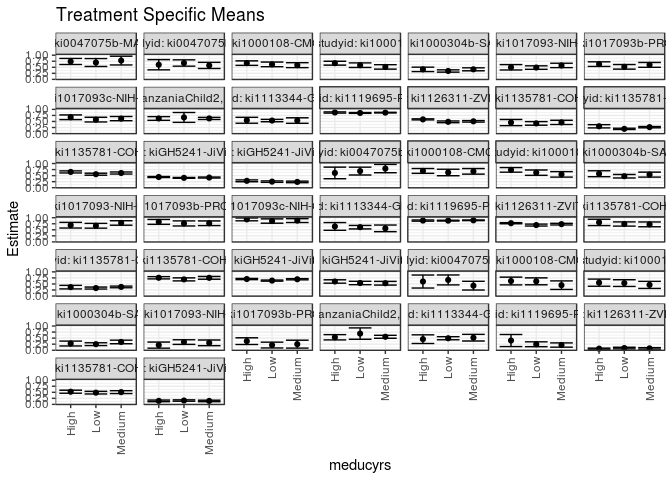

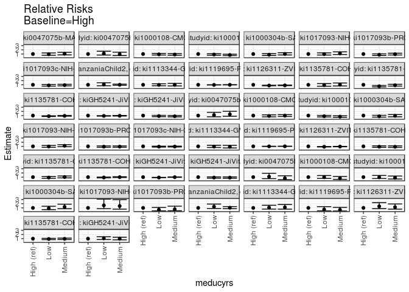

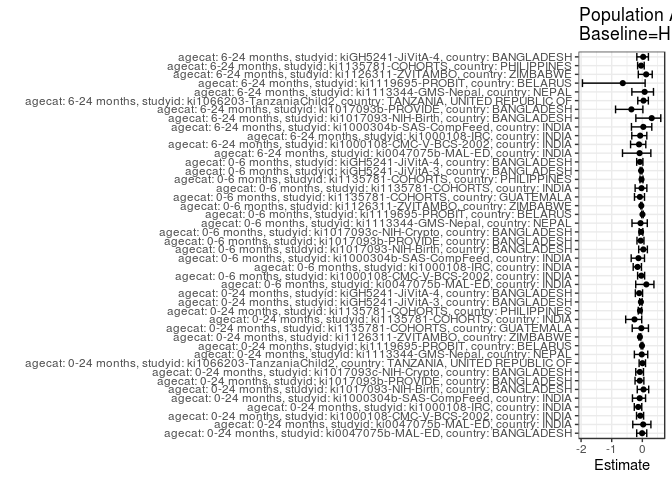

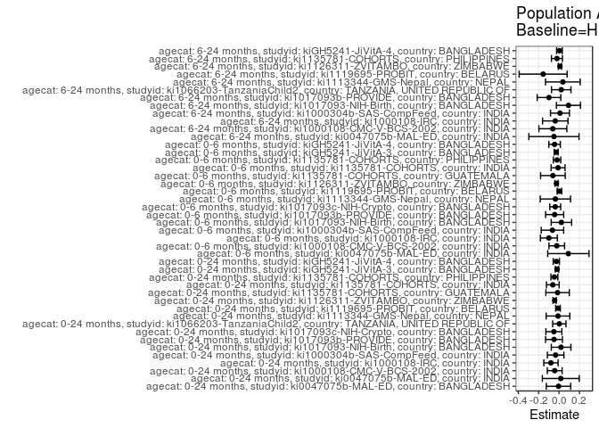

## Results Table

### Parameter: TSM

| agecat | studyid | country | intervention_level | baseline_level | estimate | ci_lower | ci_upper |
| --- | --- | --- | --- | --- | --- | --- | --- |
| 0-24 months | ki0047075b-MAL-ED | BANGLADESH | High | NA | 0.7407407 | 0.6159882 | 0.8654933 |
| 0-24 months | ki0047075b-MAL-ED | BANGLADESH | Low | NA | 0.6969697 | 0.5338973 | 0.8600421 |
| 0-24 months | ki0047075b-MAL-ED | BANGLADESH | Medium | NA | 0.7777778 | 0.5967442 | 0.9588114 |
| 0-24 months | ki0047075b-MAL-ED | INDIA | High | NA | 0.6060606 | 0.3939753 | 0.8181459 |
| 0-24 months | ki0047075b-MAL-ED | INDIA | Low | NA | 0.6774194 | 0.5469030 | 0.8079357 |
| 0-24 months | ki0047075b-MAL-ED | INDIA | Medium | NA | 0.5762712 | 0.4493613 | 0.7031810 |
| 0-24 months | ki1000108-CMC-V-BCS-2002 | INDIA | High | NA | 0.6721311 | 0.5789287 | 0.7653336 |
| 0-24 months | ki1000108-CMC-V-BCS-2002 | INDIA | Low | NA | 0.6200000 | 0.5237291 | 0.7162709 |
| 0-24 months | ki1000108-CMC-V-BCS-2002 | INDIA | Medium | NA | 0.5882353 | 0.4859084 | 0.6905622 |
| 0-24 months | ki1000108-IRC | INDIA | High | NA | 0.6692913 | 0.5896499 | 0.7489328 |
| 0-24 months | ki1000108-IRC | INDIA | Low | NA | 0.5869565 | 0.4931739 | 0.6807391 |
| 0-24 months | ki1000108-IRC | INDIA | Medium | NA | 0.5153846 | 0.4237477 | 0.6070216 |
| 0-24 months | ki1000304b-SAS-CompFeed | INDIA | High | NA | 0.4142857 | 0.3239783 | 0.5045931 |
| 0-24 months | ki1000304b-SAS-CompFeed | INDIA | Low | NA | 0.3477218 | 0.2996925 | 0.3957511 |
| 0-24 months | ki1000304b-SAS-CompFeed | INDIA | Medium | NA | 0.4163424 | 0.3547950 | 0.4778898 |
| 0-24 months | ki1017093-NIH-Birth | BANGLADESH | High | NA | 0.5000000 | 0.3889094 | 0.6110906 |
| 0-24 months | ki1017093-NIH-Birth | BANGLADESH | Low | NA | 0.4893617 | 0.4177406 | 0.5609828 |
| 0-24 months | ki1017093-NIH-Birth | BANGLADESH | Medium | NA | 0.5766423 | 0.4855823 | 0.6677024 |
| 0-24 months | ki1017093b-PROVIDE | BANGLADESH | High | NA | 0.6304348 | 0.5347873 | 0.7260822 |
| 0-24 months | ki1017093b-PROVIDE | BANGLADESH | Low | NA | 0.5188679 | 0.4238240 | 0.6139118 |
| 0-24 months | ki1017093b-PROVIDE | BANGLADESH | Medium | NA | 0.6000000 | 0.5001435 | 0.6998565 |
| 0-24 months | ki1017093c-NIH-Crypto | BANGLADESH | High | NA | 0.6732673 | 0.5763800 | 0.7701546 |
| 0-24 months | ki1017093c-NIH-Crypto | BANGLADESH | Low | NA | 0.5757576 | 0.4780742 | 0.6734410 |
| 0-24 months | ki1017093c-NIH-Crypto | BANGLADESH | Medium | NA | 0.6181818 | 0.5318955 | 0.7044682 |
| 0-24 months | ki1066203-TanzaniaChild2 | TANZANIA, UNITED REPUBLIC OF | High | NA | 0.6235955 | 0.5481204 | 0.6990706 |
| 0-24 months | ki1066203-TanzaniaChild2 | TANZANIA, UNITED REPUBLIC OF | Low | NA | 0.6666667 | 0.4628279 | 0.8705055 |
| 0-24 months | ki1066203-TanzaniaChild2 | TANZANIA, UNITED REPUBLIC OF | Medium | NA | 0.6254902 | 0.5809696 | 0.6700108 |
| 0-24 months | ki1113344-GMS-Nepal | NEPAL | High | NA | 0.5492958 | 0.4259305 | 0.6726610 |
| 0-24 months | ki1113344-GMS-Nepal | NEPAL | Low | NA | 0.5377970 | 0.4887087 | 0.5868852 |
| 0-24 months | ki1113344-GMS-Nepal | NEPAL | Medium | NA | 0.5377358 | 0.4243427 | 0.6511290 |

[output cut: 102 more lines]

### Parameter: E(Y)

| agecat | studyid | country | intervention_level | baseline_level | estimate | ci_lower | ci_upper |
| --- | --- | --- | --- | --- | --- | --- | --- |
| 0-24 months | ki0047075b-MAL-ED | BANGLADESH | NA | NA | 0.7356322 | 0.6433278 | 0.8279366 |
| 0-24 months | ki0047075b-MAL-ED | INDIA | NA | NA | 0.6233766 | 0.5382453 | 0.7085080 |
| 0-24 months | ki1000108-CMC-V-BCS-2002 | INDIA | NA | NA | 0.6296296 | 0.5734927 | 0.6857666 |
| 0-24 months | ki1000108-IRC | INDIA | NA | NA | 0.5898734 | 0.5376978 | 0.6420491 |
| 0-24 months | ki1000304b-SAS-CompFeed | INDIA | NA | NA | 0.3808354 | 0.3457640 | 0.4159068 |
| 0-24 months | ki1017093-NIH-Birth | BANGLADESH | NA | NA | 0.5201900 | 0.4695846 | 0.5707955 |
| 0-24 months | ki1017093b-PROVIDE | BANGLADESH | NA | NA | 0.5811688 | 0.5245443 | 0.6377934 |
| 0-24 months | ki1017093c-NIH-Crypto | BANGLADESH | NA | NA | 0.6225806 | 0.5684562 | 0.6767051 |
| 0-24 months | ki1066203-TanzaniaChild2 | TANZANIA, UNITED REPUBLIC OF | NA | NA | 0.6264045 | 0.5887191 | 0.6640899 |
| 0-24 months | ki1113344-GMS-Nepal | NEPAL | NA | NA | 0.5390625 | 0.4966112 | 0.5815138 |
| 0-24 months | ki1119695-PROBIT | BELARUS | NA | NA | 0.8612051 | 0.8511051 | 0.8713052 |
| 0-24 months | ki1126311-ZVITAMBO | ZIMBABWE | NA | NA | 0.5430867 | 0.5266769 | 0.5594965 |
| 0-24 months | ki1135781-COHORTS | GUATEMALA | NA | NA | 0.4403183 | 0.3884516 | 0.4921850 |
| 0-24 months | ki1135781-COHORTS | INDIA | NA | NA | 0.2397357 | 0.2214428 | 0.2580286 |
| 0-24 months | ki1135781-COHORTS | PHILIPPINES | NA | NA | 0.6068680 | 0.5823645 | 0.6313715 |
| 0-24 months | kiGH5241-JiVitA-3 | BANGLADESH | NA | NA | 0.4224309 | 0.4113024 | 0.4335594 |
| 0-24 months | kiGH5241-JiVitA-4 | BANGLADESH | NA | NA | 0.2580019 | 0.2386523 | 0.2773515 |
| 0-6 months | ki0047075b-MAL-ED | INDIA | NA | NA | 0.7027027 | 0.5947731 | 0.8106323 |
| 0-6 months | ki1000108-CMC-V-BCS-2002 | INDIA | NA | NA | 0.6716418 | 0.6057305 | 0.7375531 |
| 0-6 months | ki1000108-IRC | INDIA | NA | NA | 0.6375000 | 0.5751450 | 0.6998550 |
| 0-6 months | ki1000304b-SAS-CompFeed | INDIA | NA | NA | 0.5131965 | 0.4596632 | 0.5667297 |
| 0-6 months | ki1017093-NIH-Birth | BANGLADESH | NA | NA | 0.7130045 | 0.6535890 | 0.7724200 |
| 0-6 months | ki1017093b-PROVIDE | BANGLADESH | NA | NA | 0.7837838 | 0.7252863 | 0.8422812 |
| 0-6 months | ki1017093c-NIH-Crypto | BANGLADESH | NA | NA | 0.8934010 | 0.8497799 | 0.9370221 |
| 0-6 months | ki1113344-GMS-Nepal | NEPAL | NA | NA | 0.6030534 | 0.5432663 | 0.6628406 |
| 0-6 months | ki1119695-PROBIT | BELARUS | NA | NA | 0.8855266 | 0.8758983 | 0.8951550 |
| 0-6 months | ki1126311-ZVITAMBO | ZIMBABWE | NA | NA | 0.7474145 | 0.7304420 | 0.7643869 |
| 0-6 months | ki1135781-COHORTS | GUATEMALA | NA | NA | 0.7452830 | 0.6866274 | 0.8039386 |
| 0-6 months | ki1135781-COHORTS | INDIA | NA | NA | 0.3595188 | 0.3344897 | 0.3845478 |
| 0-6 months | ki1135781-COHORTS | PHILIPPINES | NA | NA | 0.7367021 | 0.7051294 | 0.7682749 |
| 0-6 months | kiGH5241-JiVitA-3 | BANGLADESH | NA | NA | 0.6754071 | 0.6620619 | 0.6887522 |
| 0-6 months | kiGH5241-JiVitA-4 | BANGLADESH | NA | NA | 0.5583942 | 0.5167799 | 0.6000084 |
| 6-24 months | ki0047075b-MAL-ED | INDIA | NA | NA | 0.5500000 | 0.4255057 | 0.6744943 |
| 6-24 months | ki1000108-CMC-V-BCS-2002 | INDIA | NA | NA | 0.5609756 | 0.4682842 | 0.6536670 |
| 6-24 months | ki1000108-IRC | INDIA | NA | NA | 0.5161290 | 0.4322562 | 0.6000019 |
| 6-24 months | ki1000304b-SAS-CompFeed | INDIA | NA | NA | 0.2854123 | 0.2436284 | 0.3271961 |
| 6-24 months | ki1017093-NIH-Birth | BANGLADESH | NA | NA | 0.3030303 | 0.2377927 | 0.3682679 |
| 6-24 months | ki1017093b-PROVIDE | BANGLADESH | NA | NA | 0.2764228 | 0.1950773 | 0.3577682 |
| 6-24 months | ki1066203-TanzaniaChild2 | TANZANIA, UNITED REPUBLIC OF | NA | NA | 0.5564516 | 0.5041613 | 0.6087419 |
| 6-24 months | ki1113344-GMS-Nepal | NEPAL | NA | NA | 0.4947090 | 0.4399319 | 0.5494861 |
| 6-24 months | ki1119695-PROBIT | BELARUS | NA | NA | 0.2440476 | 0.1791134 | 0.3089818 |
| 6-24 months | ki1126311-ZVITAMBO | ZIMBABWE | NA | NA | 0.0739726 | 0.0585427 | 0.0894025 |
| 6-24 months | ki1135781-COHORTS | PHILIPPINES | NA | NA | 0.5026681 | 0.4688378 | 0.5364984 |
| 6-24 months | kiGH5241-JiVitA-4 | BANGLADESH | NA | NA | 0.1492734 | 0.1316631 | 0.1668838 |

### Parameter: RR

| agecat | studyid | country | intervention_level | baseline_level | estimate | ci_lower | ci_upper |
| --- | --- | --- | --- | --- | --- | --- | --- |
| 0-24 months | ki0047075b-MAL-ED | BANGLADESH | High | High | 1.0000000 | 1.0000000 | 1.0000000 |
| 0-24 months | ki0047075b-MAL-ED | BANGLADESH | Low | High | 0.9409091 | 0.7050517 | 1.2556667 |
| 0-24 months | ki0047075b-MAL-ED | BANGLADESH | Medium | High | 1.0500000 | 0.7881118 | 1.3989132 |
| 0-24 months | ki0047075b-MAL-ED | INDIA | High | High | 1.0000000 | 1.0000000 | 1.0000000 |
| 0-24 months | ki0047075b-MAL-ED | INDIA | Low | High | 1.1177419 | 0.7494905 | 1.6669284 |
| 0-24 months | ki0047075b-MAL-ED | INDIA | Medium | High | 0.9508475 | 0.6289270 | 1.4375451 |
| 0-24 months | ki1000108-CMC-V-BCS-2002 | INDIA | High | High | 1.0000000 | 1.0000000 | 1.0000000 |
| 0-24 months | ki1000108-CMC-V-BCS-2002 | INDIA | Low | High | 0.9224390 | 0.7490783 | 1.1359210 |
| 0-24 months | ki1000108-CMC-V-BCS-2002 | INDIA | Medium | High | 0.8751793 | 0.7006785 | 1.0931389 |
| 0-24 months | ki1000108-IRC | INDIA | High | High | 1.0000000 | 1.0000000 | 1.0000000 |
| 0-24 months | ki1000108-IRC | INDIA | Low | High | 0.8769821 | 0.7185221 | 1.0703883 |
| 0-24 months | ki1000108-IRC | INDIA | Medium | High | 0.7700452 | 0.6217733 | 0.9536751 |
| 0-24 months | ki1000304b-SAS-CompFeed | INDIA | High | High | 1.0000000 | 1.0000000 | 1.0000000 |
| 0-24 months | ki1000304b-SAS-CompFeed | INDIA | Low | High | 0.8393285 | 0.6484205 | 1.0864438 |
| 0-24 months | ki1000304b-SAS-CompFeed | INDIA | Medium | High | 1.0049644 | 0.7722604 | 1.3077888 |
| 0-24 months | ki1017093-NIH-Birth | BANGLADESH | High | High | 1.0000000 | 1.0000000 | 1.0000000 |
| 0-24 months | ki1017093-NIH-Birth | BANGLADESH | Low | High | 0.9787234 | 0.7500485 | 1.2771168 |
| 0-24 months | ki1017093-NIH-Birth | BANGLADESH | Medium | High | 1.1532847 | 0.8780300 | 1.5148292 |
| 0-24 months | ki1017093b-PROVIDE | BANGLADESH | High | High | 1.0000000 | 1.0000000 | 1.0000000 |
| 0-24 months | ki1017093b-PROVIDE | BANGLADESH | Low | High | 0.8230319 | 0.6487939 | 1.0440627 |
| 0-24 months | ki1017093b-PROVIDE | BANGLADESH | Medium | High | 0.9517241 | 0.7595895 | 1.1924583 |
| 0-24 months | ki1017093c-NIH-Crypto | BANGLADESH | High | High | 1.0000000 | 1.0000000 | 1.0000000 |
| 0-24 months | ki1017093c-NIH-Crypto | BANGLADESH | Low | High | 0.8551693 | 0.6845327 | 1.0683414 |
| 0-24 months | ki1017093c-NIH-Crypto | BANGLADESH | Medium | High | 0.9181818 | 0.7509961 | 1.1225862 |
| 0-24 months | ki1066203-TanzaniaChild2 | TANZANIA, UNITED REPUBLIC OF | High | High | 1.0000000 | 1.0000000 | 1.0000000 |
| 0-24 months | ki1066203-TanzaniaChild2 | TANZANIA, UNITED REPUBLIC OF | Low | High | 1.0690691 | 0.7694770 | 1.4853058 |
| 0-24 months | ki1066203-TanzaniaChild2 | TANZANIA, UNITED REPUBLIC OF | Medium | High | 1.0030383 | 0.8716480 | 1.1542341 |
| 0-24 months | ki1113344-GMS-Nepal | NEPAL | High | High | 1.0000000 | 1.0000000 | 1.0000000 |
| 0-24 months | ki1113344-GMS-Nepal | NEPAL | Low | High | 0.9790663 | 0.7683654 | 1.2475455 |
| 0-24 months | ki1113344-GMS-Nepal | NEPAL | Medium | High | 0.9789550 | 0.7194659 | 1.3320339 |

[output cut: 102 more lines]

### Parameter: PAR

| agecat | studyid | country | intervention_level | baseline_level | estimate | ci_lower | ci_upper |
| --- | --- | --- | --- | --- | --- | --- | --- |
| 0-24 months | ki0047075b-MAL-ED | BANGLADESH | High | NA | -0.0051086 | -0.1250382 | 0.1148211 |
| 0-24 months | ki0047075b-MAL-ED | INDIA | High | NA | 0.0173160 | -0.1640166 | 0.1986487 |
| 0-24 months | ki1000108-CMC-V-BCS-2002 | INDIA | High | NA | -0.0425015 | -0.1153464 | 0.0303434 |
| 0-24 months | ki1000108-IRC | INDIA | High | NA | -0.0794179 | -0.1496332 | -0.0092026 |
| 0-24 months | ki1000304b-SAS-CompFeed | INDIA | High | NA | -0.0334503 | -0.1145728 | 0.0476722 |
| 0-24 months | ki1017093-NIH-Birth | BANGLADESH | High | NA | 0.0201900 | -0.0762664 | 0.1166465 |
| 0-24 months | ki1017093b-PROVIDE | BANGLADESH | High | NA | -0.0492660 | -0.1320918 | 0.0335599 |
| 0-24 months | ki1017093c-NIH-Crypto | BANGLADESH | High | NA | -0.0506867 | -0.1292269 | 0.0278535 |
| 0-24 months | ki1066203-TanzaniaChild2 | TANZANIA, UNITED REPUBLIC OF | High | NA | 0.0028090 | -0.0625216 | 0.0681396 |
| 0-24 months | ki1113344-GMS-Nepal | NEPAL | High | NA | -0.0102333 | -0.1269649 | 0.1064984 |
| 0-24 months | ki1119695-PROBIT | BELARUS | High | NA | -0.0102234 | -0.0330823 | 0.0126355 |
| 0-24 months | ki1126311-ZVITAMBO | ZIMBABWE | High | NA | -0.0430466 | -0.0587924 | -0.0273009 |
| 0-24 months | ki1135781-COHORTS | GUATEMALA | High | NA | -0.0142272 | -0.1296158 | 0.1011615 |
| 0-24 months | ki1135781-COHORTS | INDIA | High | NA | -0.0612351 | -0.1236466 | 0.0011763 |
| 0-24 months | ki1135781-COHORTS | PHILIPPINES | High | NA | -0.0460530 | -0.0800300 | -0.0120759 |
| 0-24 months | kiGH5241-JiVitA-3 | BANGLADESH | High | NA | -0.0199012 | -0.0364019 | -0.0034004 |
| 0-24 months | kiGH5241-JiVitA-4 | BANGLADESH | High | NA | -0.0267981 | -0.0573297 | 0.0037336 |
| 0-6 months | ki0047075b-MAL-ED | INDIA | High | NA | 0.0915916 | -0.1113297 | 0.2945128 |
| 0-6 months | ki1000108-CMC-V-BCS-2002 | INDIA | High | NA | -0.0224759 | -0.0991844 | 0.0542326 |
| 0-6 months | ki1000108-IRC | INDIA | High | NA | -0.1000000 | -0.1831640 | -0.0168360 |
| 0-6 months | ki1000304b-SAS-CompFeed | INDIA | High | NA | -0.0649285 | -0.1753035 | 0.0454464 |
| 0-6 months | ki1017093-NIH-Birth | BANGLADESH | High | NA | 0.0233493 | -0.0772956 | 0.1239942 |
| 0-6 months | ki1017093b-PROVIDE | BANGLADESH | High | NA | -0.0431393 | -0.1318940 | 0.0456154 |
| 0-6 months | ki1017093c-NIH-Crypto | BANGLADESH | High | NA | -0.0371545 | -0.0905895 | 0.0162804 |
| 0-6 months | ki1113344-GMS-Nepal | NEPAL | High | NA | -0.0358355 | -0.1848370 | 0.1131660 |
| 0-6 months | ki1119695-PROBIT | BELARUS | High | NA | 0.0037748 | -0.0185226 | 0.0260722 |
| 0-6 months | ki1126311-ZVITAMBO | ZIMBABWE | High | NA | -0.0252141 | -0.0407077 | -0.0097204 |
| 0-6 months | ki1135781-COHORTS | GUATEMALA | High | NA | -0.0602725 | -0.1812521 | 0.0607071 |
| 0-6 months | ki1135781-COHORTS | INDIA | High | NA | -0.0095289 | -0.0779948 | 0.0589371 |
| 0-6 months | ki1135781-COHORTS | PHILIPPINES | High | NA | -0.0194707 | -0.0556037 | 0.0166623 |
| 0-6 months | kiGH5241-JiVitA-3 | BANGLADESH | High | NA | -0.0282220 | -0.0476426 | -0.0088014 |
| 0-6 months | kiGH5241-JiVitA-4 | BANGLADESH | High | NA | -0.0437001 | -0.1002157 | 0.0128156 |
| 6-24 months | ki0047075b-MAL-ED | INDIA | High | NA | -0.0500000 | -0.2964156 | 0.1964156 |
| 6-24 months | ki1000108-CMC-V-BCS-2002 | INDIA | High | NA | -0.0606460 | -0.1979452 | 0.0766532 |
| 6-24 months | ki1000108-IRC | INDIA | High | NA | -0.0370625 | -0.1621908 | 0.0880659 |
| 6-24 months | ki1000304b-SAS-CompFeed | INDIA | High | NA | 0.0090965 | -0.0838805 | 0.1020735 |
| 6-24 months | ki1017093-NIH-Birth | BANGLADESH | High | NA | 0.0925040 | -0.0259710 | 0.2109790 |
| 6-24 months | ki1017093b-PROVIDE | BANGLADESH | High | NA | -0.0985772 | -0.2149020 | 0.0177476 |
| 6-24 months | ki1066203-TanzaniaChild2 | TANZANIA, UNITED REPUBLIC OF | High | NA | 0.0215679 | -0.0739879 | 0.1171237 |
| 6-24 months | ki1113344-GMS-Nepal | NEPAL | High | NA | 0.0375661 | -0.1330119 | 0.2081442 |
| 6-24 months | ki1119695-PROBIT | BELARUS | High | NA | -0.1559524 | -0.3917880 | 0.0798833 |
| 6-24 months | ki1126311-ZVITAMBO | ZIMBABWE | High | NA | 0.0091953 | -0.0075944 | 0.0259849 |
| 6-24 months | ki1135781-COHORTS | PHILIPPINES | High | NA | -0.0205877 | -0.0746697 | 0.0334943 |
| 6-24 months | kiGH5241-JiVitA-4 | BANGLADESH | High | NA | 0.0041122 | -0.0239439 | 0.0321682 |

### Parameter: PAF

| agecat | studyid | country | intervention_level | baseline_level | estimate | ci_lower | ci_upper |
| --- | --- | --- | --- | --- | --- | --- | --- |
| 0-24 months | ki0047075b-MAL-ED | BANGLADESH | High | NA | -0.0069444 | -0.1842556 | 0.1438190 |
| 0-24 months | ki0047075b-MAL-ED | INDIA | High | NA | 0.0277778 | -0.3121485 | 0.2796425 |
| 0-24 months | ki1000108-CMC-V-BCS-2002 | INDIA | High | NA | -0.0675024 | -0.1896862 | 0.0421328 |
| 0-24 months | ki1000108-IRC | INDIA | High | NA | -0.1346355 | -0.2631337 | -0.0192094 |
| 0-24 months | ki1000304b-SAS-CompFeed | INDIA | High | NA | -0.0878341 | -0.3227226 | 0.1053430 |
| 0-24 months | ki1017093-NIH-Birth | BANGLADESH | High | NA | 0.0388128 | -0.1659758 | 0.2076329 |
| 0-24 months | ki1017093b-PROVIDE | BANGLADESH | High | NA | -0.0847705 | -0.2382630 | 0.0496955 |
| 0-24 months | ki1017093c-NIH-Crypto | BANGLADESH | High | NA | -0.0814138 | -0.2151719 | 0.0376210 |
| 0-24 months | ki1066203-TanzaniaChild2 | TANZANIA, UNITED REPUBLIC OF | High | NA | 0.0044843 | -0.1054703 | 0.1035023 |
| 0-24 months | ki1113344-GMS-Nepal | NEPAL | High | NA | -0.0189835 | -0.2603042 | 0.1761296 |
| 0-24 months | ki1119695-PROBIT | BELARUS | High | NA | -0.0118711 | -0.0387686 | 0.0143300 |
| 0-24 months | ki1126311-ZVITAMBO | ZIMBABWE | High | NA | -0.0792629 | -0.1087899 | -0.0505221 |
| 0-24 months | ki1135781-COHORTS | GUATEMALA | High | NA | -0.0323111 | -0.3305284 | 0.1990655 |
| 0-24 months | ki1135781-COHORTS | INDIA | High | NA | -0.2554277 | -0.5435995 | -0.0210542 |
| 0-24 months | ki1135781-COHORTS | PHILIPPINES | High | NA | -0.0758863 | -0.1333771 | -0.0213118 |
| 0-24 months | kiGH5241-JiVitA-3 | BANGLADESH | High | NA | -0.0471111 | -0.0869277 | -0.0087530 |
| 0-24 months | kiGH5241-JiVitA-4 | BANGLADESH | High | NA | -0.1038677 | -0.2282322 | 0.0079044 |
| 0-6 months | ki0047075b-MAL-ED | INDIA | High | NA | 0.1303419 | -0.2160862 | 0.3780825 |
| 0-6 months | ki1000108-CMC-V-BCS-2002 | INDIA | High | NA | -0.0334641 | -0.1543867 | 0.0747918 |
| 0-6 months | ki1000108-IRC | INDIA | High | NA | -0.1568627 | -0.2987948 | -0.0304410 |
| 0-6 months | ki1000304b-SAS-CompFeed | INDIA | High | NA | -0.1265179 | -0.3641821 | 0.0697412 |
| 0-6 months | ki1017093-NIH-Birth | BANGLADESH | High | NA | 0.0327478 | -0.1192818 | 0.1641275 |
| 0-6 months | ki1017093b-PROVIDE | BANGLADESH | High | NA | -0.0550398 | -0.1751448 | 0.0527900 |
| 0-6 months | ki1017093c-NIH-Crypto | BANGLADESH | High | NA | -0.0415878 | -0.1037496 | 0.0170732 |
| 0-6 months | ki1113344-GMS-Nepal | NEPAL | High | NA | -0.0594233 | -0.3378167 | 0.1610377 |
| 0-6 months | ki1119695-PROBIT | BELARUS | High | NA | 0.0042628 | -0.0212388 | 0.0291276 |
| 0-6 months | ki1126311-ZVITAMBO | ZIMBABWE | High | NA | -0.0337350 | -0.0547511 | -0.0131377 |
| 0-6 months | ki1135781-COHORTS | GUATEMALA | High | NA | -0.0808720 | -0.2567513 | 0.0703934 |
| 0-6 months | ki1135781-COHORTS | INDIA | High | NA | -0.0265045 | -0.2357540 | 0.1473129 |
| 0-6 months | ki1135781-COHORTS | PHILIPPINES | High | NA | -0.0264296 | -0.0767165 | 0.0215088 |
| 0-6 months | kiGH5241-JiVitA-3 | BANGLADESH | High | NA | -0.0417851 | -0.0709815 | -0.0133847 |
| 0-6 months | kiGH5241-JiVitA-4 | BANGLADESH | High | NA | -0.0782603 | -0.1846919 | 0.0186097 |
| 6-24 months | ki0047075b-MAL-ED | INDIA | High | NA | -0.0909091 | -0.6477166 | 0.2777383 |
| 6-24 months | ki1000108-CMC-V-BCS-2002 | INDIA | High | NA | -0.1081081 | -0.3842876 | 0.1129708 |
| 6-24 months | ki1000108-IRC | INDIA | High | NA | -0.0718085 | -0.3447259 | 0.1457192 |
| 6-24 months | ki1000304b-SAS-CompFeed | INDIA | High | NA | 0.0318713 | -0.3552642 | 0.3084204 |
| 6-24 months | ki1017093-NIH-Birth | BANGLADESH | High | NA | 0.3052632 | -0.2119312 | 0.6017437 |
| 6-24 months | ki1017093b-PROVIDE | BANGLADESH | High | NA | -0.3566176 | -0.8742527 | 0.0180559 |
| 6-24 months | ki1066203-TanzaniaChild2 | TANZANIA, UNITED REPUBLIC OF | High | NA | 0.0387597 | -0.1493241 | 0.1960641 |
| 6-24 months | ki1113344-GMS-Nepal | NEPAL | High | NA | 0.0759358 | -0.3421075 | 0.3637659 |
| 6-24 months | ki1119695-PROBIT | BELARUS | High | NA | -0.6390244 | -1.9550955 | 0.0909258 |
| 6-24 months | ki1126311-ZVITAMBO | ZIMBABWE | High | NA | 0.1243065 | -0.1321830 | 0.3226898 |
| 6-24 months | ki1135781-COHORTS | PHILIPPINES | High | NA | -0.0409569 | -0.1544335 | 0.0613654 |
| 6-24 months | kiGH5241-JiVitA-4 | BANGLADESH | High | NA | 0.0275478 | -0.1799116 | 0.1985304 |